# Random Spatial Network Generation

Aishwarya Venkat

June 14, 2017

### Loading data

Let’s create some data to test this method with. We will generate 100 random points within Egypt’s national borders. Note: explore removing water bodies from this extent?

### Generating Voronoi Polygons

### Randomly sample within Voronoi polygons

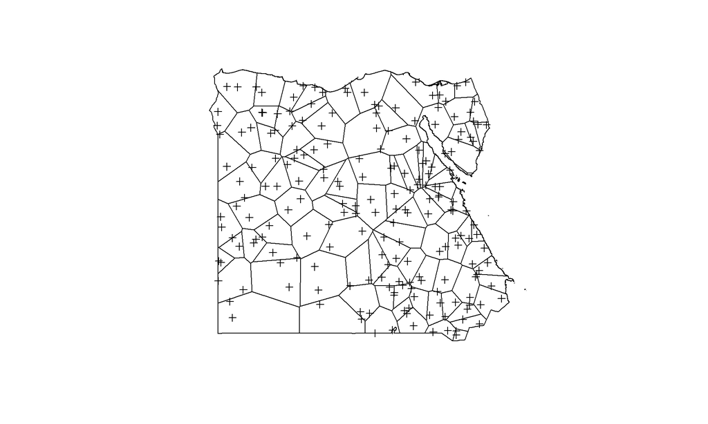

### Build Watts-Strogatz model

First, we build a Watts-Strogatz small-world model based on the derived points. We will also assign it a random farm size value between 1 and 100.

### Build “real-world” model

This function derives network and community characteristics from the points. The outputs are added to the global environment with a prefix of choice

### Watts-Strogatz Model

We can use the above loop to extract network and vertex characteristics to better understand potential differences between the models. We can also build communities to identify potential trade partners or hubs (markets).

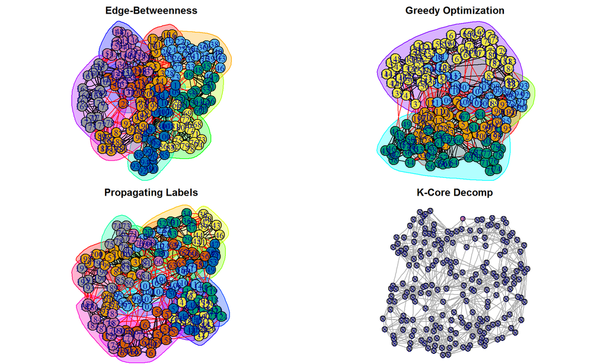

```
##   Assortativity_FarmSize Assortativity_Degree Transitivity_Global
## 1            -0.04291634          0.003768117           0.4798551
```

```
##          Closeness             Degree          Hub_Score
##        0.001571175        0.050251256        0.632884978
##    AuthoritY_Score Transitivity_Local               <NA>
##        0.632884978        0.489413808                 NA
```

### “Real World” Model

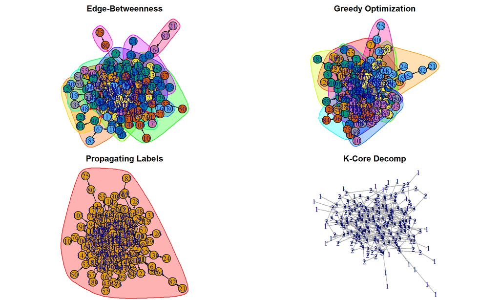

```
##   Assortativity_FarmSize Assortativity_Degree Transitivity_Global
## 1            -0.07474943          -0.03095774          0.03082192
```

```
##          Closeness             Degree          Hub_Score
##        0.001279164        0.019884877        0.072316986
##    AuthoritY_Score Transitivity_Local               <NA>
##        0.068845480                NaN                 NA
```